# PEMODELAN IHSG DENGAN ARIMA SERTA ANALISIS OUTLIER DAN INTERVENSI

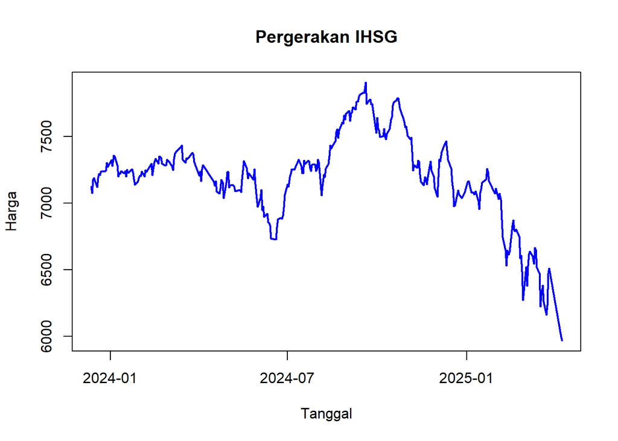

```r
> plot(Tanggal, Harga, type = "l", col = "blue", lwd = 2,
+      main = "Pergerakan IHSG")
```

Kondisi tersebut menjadi dasar penggunaan model ARIMA Intervensi untuk menangkap efek guncangan secara lebih akurat. Selain itu, pemodelan juga dilakukan menggunakan ARIMA Outlier untuk mengakomodasi adanya nilai pencilan pada data.

Pemodelan ARIMA Intervensi diawali dengan pembentukan model ARIMA pada data pra-intervensi, yaitu periode 12 Desember 2023 hingga 19 Maret 2025. Tahap ini bertujuan untuk memperoleh model terbaik yang mampu merepresentasikan perilaku data dalam kondisi normal. Selanjutnya, efek kebijakan pengesahan RUU TNI pada 20 Maret 2025 diintegrasikan ke dalam model untuk mengukur besarnya perubahan yang terjadi.

Sementara itu, pemodelan ARIMA Outlier digunakan untuk mengidentifikasi dan menyesuaikan pengaruh nilai-nilai ekstrem yang muncul pada data, sehingga model yang dihasilkan tetap stabil dan mampu memberikan hasil peramalan yang lebih akurat.

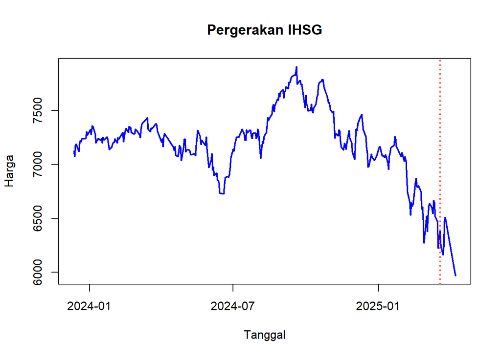

```r
> plot(Tanggal, Harga, type = "l", col = "blue", lwd = 2,
+      main = "Pergerakan IHSG")
> abline(v = Tanggal[304], col = "red", lty = 3, lwd = 1.5)
```

# Statistik Deskriptif Harga Penutupan IHSG

Statistik deskriptif digunakan untuk memberikan gambaran ringkas mengenai karakteristik data harga penutupan IHSG selama periode Desember 2023 hingga April 2025.

```r
> summary(data.saham)
    Tanggal               Harga
 Min.   :2023-12-12   Min.   :5968
 1st Qu.:2024-04-17   1st Qu.:7084
 Median :2024-08-13   Median :7234
 Mean   :2024-08-08   Mean   :7197
 3rd Qu.:2024-12-02   3rd Qu.:7339
 Max.   :2025-04-09   Max.   :7905
```

Hasil statistik deskriptif menunjukkan bahwa rata-rata (mean) harga penutupan IHSG sebesar 7.197 dengan median 7.234. Rentang nilai yang cukup lebar, dari 5.968 hingga 7.905, mencerminkan pergerakan indeks yang dinamis. Selain itu, 50% data berada pada kisaran 7.084 hingga 7.339 (Q1–Q3). Secara keseluruhan, hal ini menunjukkan adanya fluktuasi yang cukup tinggi pada IHSG selama periode pengamatan.

# Pemodelan ARIMA Outlier

Pemodelan ARIMA Outlier dilakukan melalui tahapan yang serupa dengan prosedur ARIMA pada umumnya. Perbedaannya terletak pada adanya proses identifikasi dan penanganan nilai pencilan, khususnya Additive Outlier (AO) dan Innovative Outlier (IO).

## Uji Stasioneritas Data

### Pemeriksaan stasioneritas terhadap ragam

```r
> Harga.ujiragam = Harga - min(Harga)+1
> BoxCox.lambda(Harga.ujiragam)
[1] 1.467291
```

### Stasioneritas terhadap Rata-Rata

Dalam pemodelan ARIMA, data deret waktu yang digunakan harus bersifat stasioner terhadap rata-rata. Pengujian kondisi tersebut dapat dilakukan melalui uji Dickey-Fuller dengan hipotesis sebagai berikut.  
$H_0$ : $\phi=1$ (data tidak stasioner terhadap rata-rata) vs  
$H_1$ : $\phi<1$ (data stasioner terhadap rata-rata)  
Taraf nyata: $\alpha=0,05$  
Daerah penolakan: apabila nilai-p kurang dari 0,05 maka $H_0$ ditolak yang artinya data stasioner terhadap rata-rata

```r
> adf.test(Harga, k=1)

    Augmented Dickey-Fuller Test

data:  Harga
Dickey-Fuller = -0.85579, Lag order = 1, p-value = 0.9559
alternative hypothesis: stationary
```

Hasil uji Dickey-Fuller menunjukkan bahwa p-value sebesar $0,9559$ lebih besar dari $\alpha=0,05$, sehingga gagal menolak $H_0$. Hal ini mengindikasikan bahwa data harga belum stasioner terhadap rata-rata. Oleh karena itu, diperlukan proses differencing (pembedaan) agar data menjadi stasioner sebelum dilakukan pemodelan ARIMA.

### Proses Differencing

Berdasarkan hasil uji Dickey-Fuller, data belum stasioner terhadap rata-rata. Oleh karena itu, dilakukan proses differencing orde pertama untuk menghilangkan tren dan mencapai kondisi stasioner.

```r
> df_diff = diff(data.saham$Harga)
> adf.test(df_diff)

    Augmented Dickey-Fuller Test

data:  df_diff
Dickey-Fuller = -7.703, Lag order = 6, p-value = 0.01
alternative hypothesis: stationary
```

Hasil uji Augmented Dickey-Fuller pada data setelah differencing menunjukkan p-value sebesar $0,01$ < $\alpha(0,05)$, sehingga $H_0$ ditolak. Hal ini mengindikasikan bahwa data telah stasioner terhadap rata-rata. Dengan demikian, differencing orde pertama ($d = 1$) sudah cukup untuk memenuhi asumsi stasioneritas sebelum dilakukan pemodelan ARIMA.

## Identifikasi Model ARIMA

Identifikasi model ARIMA dilakukan menggunakan plot ACF dan PACF. Plot ACF dan PACF digunakan untuk menentukan orde $p$ dan $q$ pada model ARIMA. Analisis ACF dan PACF dilakukan pada data yang telah distasionerkan melalui proses differencing.

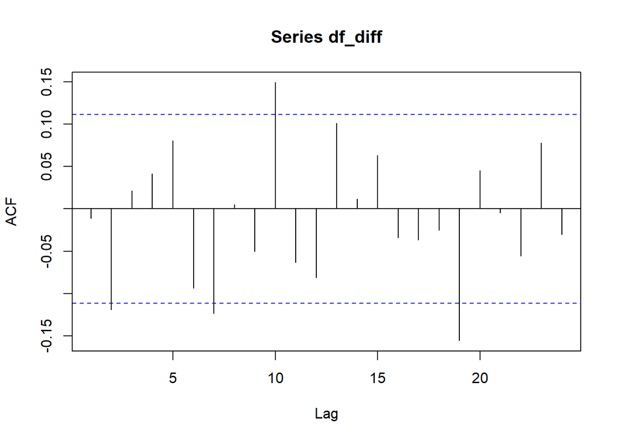

```r
> acf(df_diff)
```

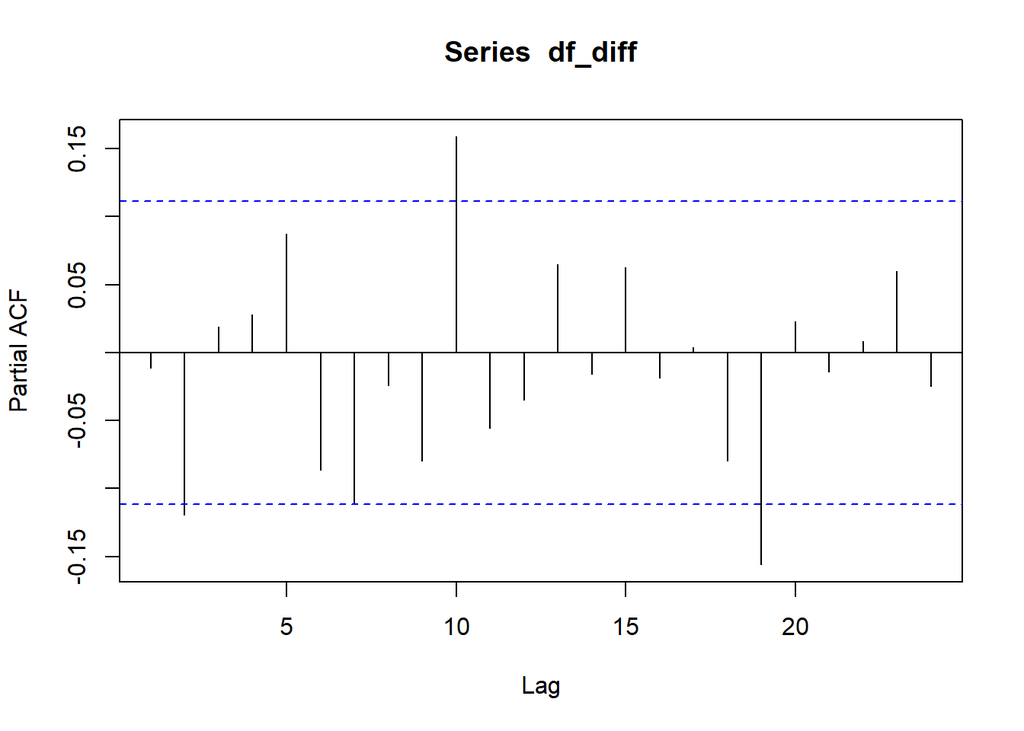

```r
> pacf(df_diff)
```

Berdasarkan plot ACF dan PACF pada data hasil differencing, terlihat beberapa lag yang signifikan. Pada plot ACF, lag signifikan muncul pada lag ke-2, 7, 10, dan 19, sedangkan pada plot PACF terlihat pada lag ke-2, 10, dan 19.

Kondisi ini menunjukkan adanya indikasi komponen Moving Average (MA) pada ACF serta Autoregressive (AR) pada PACF. Kemunculan lag signifikan yang tidak berurutan mengindikasikan bahwa model yang sesuai adalah ARIMA restricted, yaitu model yang hanya memasukkan parameter pada lag-lag tertentu saja.

Berdasarkan hal tersebut, kandidat model yang dapat digunakan adalah ARIMA([2,10,19],1,0) untuk komponen AR dan ARIMA(0,1,[2,7,10,19]) untuk komponen MA.

## Pendugaan Parameter Model ARIMA

```r
> pola_fixed1 = c(0, NA,rep(0, 7),NA, rep(0, 8),NA)
> arima1 = arima(Harga,
+                  order = c(19, 1, 0),
+                  fixed = pola_fixed1,
+                  method = 'ML',
+                 include.mean = TRUE)
> coeftest(arima1)

z test of coefficients:

      Estimate Std. Error z value Pr(>|z|)
ar2  -0.123401   0.059480 -2.0747 0.038018 *
ar10  0.170636   0.062387  2.7351 0.006236 **
ar19 -0.191446   0.063179 -3.0302 0.002444 **
---
Signif. codes:  0 '***' 0.001 '**' 0.01 '*' 0.05 '.' 0.1 ' ' 1
```

```r
> pola_fixed2 = c(0, NA,rep(0, 4),NA, 0, 0,NA,rep(0, 8),NA)
> arima2 = arima(Harga,
+                  order = c(0, 1, 19),
+                  fixed = pola_fixed2,
+                  method = 'ML',
+                 include.mean = TRUE)
> coeftest(arima2)

z test of coefficients:

      Estimate Std. Error z value Pr(>|z|)
ma2  -0.096868   0.054647 -1.7726 0.076294 .
ma7  -0.127668   0.055612 -2.2957 0.021694 *
ma10  0.120976   0.058198  2.0787 0.037645 *
ma19 -0.177817   0.060364 -2.9457 0.003222 **
---
Signif. codes:  0 '***' 0.001 '**' 0.01 '*' 0.05 '.' 0.1 ' ' 1
```

Berdasarkan hasil uji signifikansi parameter pada model ARIMA, diketahui bahwa seluruh parameter AR, yaitu AR(2), AR(10), dan AR(19), memiliki p-value kurang dari $0,05$. Hal ini menunjukkan bahwa parameter tersebut signifikan secara statistik pada tingkat signifikansi$\alpha=0,05$, sehingga model layak digunakan untuk analisis dan peramalan.

Sementara itu, pada komponen MA, parameter MA(2) tidak signifikan karena memiliki p-value lebih besar dari $0,05$. Oleh karena itu, parameter MA(2) dikeluarkan dari model, sedangkan parameter MA(7), MA(10), dan MA(19) tetap dipertahankan.

Selanjutnya, dilakukan pemodelan ulang dengan menghilangkan MA(2) untuk memperoleh model yang lebih sederhana namun tetap signifikan secara statistik.

```r
> pola_fixed3 = c(rep(0,6),NA, 0, 0,NA,rep(0, 8),NA)
> arima3 = arima(Harga,
+                  order = c(0, 1, 19),
+                  fixed = pola_fixed3,
+                  method = 'ML',
+                 include.mean = TRUE)
> coeftest(arima3)

z test of coefficients:

      Estimate Std. Error z value Pr(>|z|)
ma7  -0.129664   0.056762 -2.2843 0.022352 *
ma10  0.137507   0.058432  2.3533 0.018608 *
ma19 -0.173809   0.061461 -2.8279 0.004685 **
---
Signif. codes:  0 '***' 0.001 '**' 0.01 '*' 0.05 '.' 0.1 ' ' 1
```

Berdasarkan hasil uji signifikansi parameter setelah dilakukan modifikasi model, seluruh parameter Moving Average (MA), yaitu MA(7), MA(10), dan MA(19), memiliki p-value kurang dari $0,05$. Hal ini menunjukkan bahwa seluruh parameter signifikan secara statistik.

Dengan demikian, model ARIMA hasil revisi telah memenuhi kriteria signifikansi parameter dan dapat digunakan untuk analisis lebih lanjut.

## Uji Asumsi Sisaan

Tahap berikutnya adalah melakukan pengujian asumsi residual, yang meliputi uji autokorelasi dan normalitas. Adapun hipotesis yang digunakan dalam uji autokorelasi residual adalah sebagai berikut.  
$H_0$ : $\rho_1=\rho_2=...=\rho_k=0$ (tidak terdapat autokorelasi pada sisaan) vs $H_1$ : minimal terdapat satu $\rho_k \neq 0$ ( terdapat autokorelasi pada sisaan) Taraf nyata: $0,05$

```r
> resarima1 = residuals(arima1)
> resarima3 = residuals(arima3)
> Box.test(resarima1, lag=2, type = c('Ljung-Box'))

    Box-Ljung test

data:  resarima1
X-squared = 0.14256, df = 2, p-value = 0.9312
> Box.test(resarima1, lag=6, type = c('Ljung-Box'))

    Box-Ljung test

data:  resarima1
X-squared = 4.1667, df = 6, p-value = 0.6541
> Box.test(resarima1, lag=20, type = c('Ljung-Box'))

    Box-Ljung test

data:  resarima1
X-squared = 19.039, df = 20, p-value = 0.5193
> Box.test(resarima3, lag=2, type = c('Ljung-Box'))

    Box-Ljung test

data:  resarima3
X-squared = 3.9754, df = 2, p-value = 0.137
> Box.test(resarima3, lag=6, type = c('Ljung-Box'))

    Box-Ljung test

data:  resarima3
X-squared = 8.4738, df = 6, p-value = 0.2054
> Box.test(resarima3, lag=20, type = c('Ljung-Box'))

    Box-Ljung test

data:  resarima3
X-squared = 19.101, df = 20, p-value = 0.5153
```

Berdasarkan hasil uji white noise, residual model tidak menunjukkan adanya autokorelasi yang signifikan, yang ditunjukkan oleh nilai p-value seluruhnya lebih besar dari $0,05$. Dengan demikian, $H_0$ diterima. Hal ini mengindikasikan bahwa residual bersifat acak (white noise). Oleh karena itu, model telah memenuhi asumsi tidak adanya autokorelasi dan dapat dilanjutkan ke tahap berikutnya, yaitu uji normalitas residual.

Uji normalitas sisaan menggunakan uji Jarque Bera dengan hipotesis sebagai berikut. $H_0$ : $\epsilon_i\sim N(0, \sigma_e^{2})$ (sisaan menyebar normal) vs $H_1$ : $\varepsilon\not\sim N(0, \sigma_e^2)$ (sisaan tidak menyebar normal) Taraf nyata: $0,05$

```r
> jarque.bera.test(resarima1)

    Jarque Bera Test

data:  resarima1
X-squared = 223.39, df = 2, p-value < 2.2e-16
> jarque.bera.test(resarima3)

    Jarque Bera Test

data:  resarima3
X-squared = 426.33, df = 2, p-value < 2.2e-16
```

Hasil uji normalitas residual menunjukkan p-value yang sangat kecil ($<2,2e-16$), sehingga $H_0$ ditolak. Hal ini mengindikasikan bahwa residual model tidak berdistribusi normal.Meskipun demikian, ketidaknormalan residual merupakan hal yang umum terjadi pada data keuangan seperti IHSG yang memiliki volatilitas tinggi. Selama residual telah memenuhi asumsi white noise, model ARIMA tetap dapat digunakan untuk peramalan. Setelah seluruh asumsi terpenuhi, maka dapat dilanjutkan pemilihan model terbaik dengan AIC.

## Pemilihan Model Terbaik

```r
> arima1$aic
[1] 3539.839
> arima3$aic
[1] 3541.331
```

Berdasarkan perbandingan nilai Akaike Information Criterion (AIC), model AR menunjukkan nilai AIC yang lebih rendah dibandingkan dengan model MA. Hal ini mengindikasikan bahwa model AR memiliki tingkat kecocokan yang lebih baik terhadap data.

Oleh karena itu, model terbaik yang dipilih adalah ARIMA([2,10,19],1,0).

## Deteksi Outlier

Berdasarkan plot data deret waktu harga penutupan IHSG, terlihat adanya beberapa titik ekstrem pada data. Kondisi ini mengindikasikan kemungkinan adanya outlier yang dapat mempengaruhi hasil pemodelan ARIMA.

```r
> pred.arima = Harga-resarima1
> outlier = tso(pred.arima, types = c('AO','IO','IS','TC'))
> print(outlier)
Series: pred.arima
Regression with ARIMA(0,1,0) errors

Coefficients:
          TC151     AO292      AO311
      -251.9818  225.5138  -400.6103
s.e.    61.6684   47.2975    66.8888

sigma^2 = 4518:  log likelihood = -1742.81
AIC=3493.62   AICc=3493.75   BIC=3508.57

Outliers:
  type ind time coefhat  tstat
1   TC 151  151  -252.0 -4.086
2   AO 292  292   225.5  4.768
3   AO 311  311  -400.6 -5.989
```

Berdasarkan hasil pengujian, teridentifikasi tiga pencilan signifikan pada data IHSG, yaitu satu Temporary Change (TC) pada periode ke-151 dan dua Additive Outlier (AO) pada periode ke-292 dan ke-311. Nilai koefisien dan t-statistik yang signifikan menunjukkan adanya guncangan ekstrem dan kejutan pasar yang bersifat sementara. Hal ini mengindikasikan volatilitas tinggi yang berpotensi memengaruhi kestabilan model ARIMA.

Untuk melihat efek dari pencilan AO dan TC terhadap data, dapat diamati pada plot berikut.

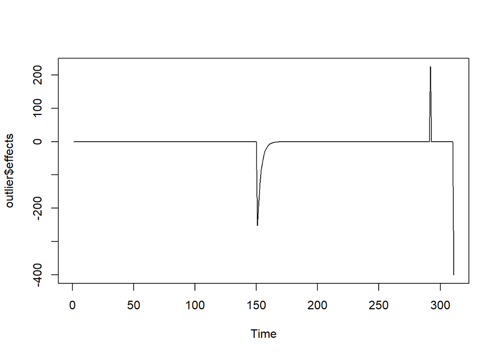

```r
> plot(outlier$effects)
```